# Project: Wrangling and Analyze Data

## Data Gathering

In the cell below, gather **all** three pieces of data for this project and load them in the notebook. **Note:** the methods required to gather each data are different.

1. Directly download the WeRateDogs Twitter archive data (twitter_archive_enhanced.csv)

```python
import requests
import pandas as pd
import tweepy
df_archive = pd.read_csv("twitter-archive-enhanced.csv")
```

```python
df_archive.info()
```

```
<class 'pandas.core.frame.DataFrame'>
RangeIndex: 2356 entries, 0 to 2355
Data columns (total 17 columns):
 #   Column                      Non-Null Count  Dtype
---  ------                      --------------  -----
 0   tweet_id                    2356 non-null   int64
 1   in_reply_to_status_id       78 non-null     float64
 2   in_reply_to_user_id         78 non-null     float64
 3   timestamp                   2356 non-null   object
 4   source                      2356 non-null   object
 5   text                        2356 non-null   object
 6   retweeted_status_id         181 non-null    float64
 7   retweeted_status_user_id    181 non-null    float64
 8   retweeted_status_timestamp  181 non-null    object
 9   expanded_urls               2297 non-null   object
 10  rating_numerator            2356 non-null   int64
 11  rating_denominator          2356 non-null   int64
 12  name                        2356 non-null   object
 13  doggo                       2356 non-null   object
 14  floofer                     2356 non-null   object
 15  pupper                      2356 non-null   object
 16  puppo                       2356 non-null   object
dtypes: float64(4), int64(3), object(10)
memory usage: 313.0+ KB
```

```python
df_archive.head(5)
```

|  | tweet_id | in_reply_to_status_id | in_reply_to_user_id | timestamp | source | text | retweeted_status_id | retweeted_status_user_id | retweeted_status_timestamp | expanded_urls | rating_numerator | rating_denominator | name | doggo | floofer | pupper | puppo |
| --- | --- | --- | --- | --- | --- | --- | --- | --- | --- | --- | --- | --- | --- | --- | --- | --- | --- |
| 0 | 892420643555336193 | NaN | NaN | 2017-08-01 16:23:56 +0000 | <a href="http://twitter.com/download/iphone" r... | This is Phineas. He's a mystical boy. Only eve... | NaN | NaN | NaN | https://twitter.com/dog_rates/status/892420643... | 13 | 10 | Phineas | None | None | None | None |
| 1 | 892177421306343426 | NaN | NaN | 2017-08-01 00:17:27 +0000 | <a href="http://twitter.com/download/iphone" r... | This is Tilly. She's just checking pup on you.... | NaN | NaN | NaN | https://twitter.com/dog_rates/status/892177421... | 13 | 10 | Tilly | None | None | None | None |
| 2 | 891815181378084864 | NaN | NaN | 2017-07-31 00:18:03 +0000 | <a href="http://twitter.com/download/iphone" r... | This is Archie. He is a rare Norwegian Pouncin... | NaN | NaN | NaN | https://twitter.com/dog_rates/status/891815181... | 12 | 10 | Archie | None | None | None | None |
| 3 | 891689557279858688 | NaN | NaN | 2017-07-30 15:58:51 +0000 | <a href="http://twitter.com/download/iphone" r... | This is Darla. She commenced a snooze mid meal... | NaN | NaN | NaN | https://twitter.com/dog_rates/status/891689557... | 13 | 10 | Darla | None | None | None | None |
| 4 | 891327558926688256 | NaN | NaN | 2017-07-29 16:00:24 +0000 | <a href="http://twitter.com/download/iphone" r... | This is Franklin. He would like you to stop ca... | NaN | NaN | NaN | https://twitter.com/dog_rates/status/891327558... | 12 | 10 | Franklin | None | None | None | None |

```python
df_archive.describe()
```

|  | tweet_id | in_reply_to_status_id | in_reply_to_user_id | retweeted_status_id | retweeted_status_user_id | rating_numerator | rating_denominator |
| --- | --- | --- | --- | --- | --- | --- | --- |
| count | 2.356000e+03 | 7.800000e+01 | 7.800000e+01 | 1.810000e+02 | 1.810000e+02 | 2356.000000 | 2356.000000 |
| mean | 7.427716e+17 | 7.455079e+17 | 2.014171e+16 | 7.720400e+17 | 1.241698e+16 | 13.126486 | 10.455433 |
| std | 6.856705e+16 | 7.582492e+16 | 1.252797e+17 | 6.236928e+16 | 9.599254e+16 | 45.876648 | 6.745237 |
| min | 6.660209e+17 | 6.658147e+17 | 1.185634e+07 | 6.661041e+17 | 7.832140e+05 | 0.000000 | 0.000000 |
| 25% | 6.783989e+17 | 6.757419e+17 | 3.086374e+08 | 7.186315e+17 | 4.196984e+09 | 10.000000 | 10.000000 |
| 50% | 7.196279e+17 | 7.038708e+17 | 4.196984e+09 | 7.804657e+17 | 4.196984e+09 | 11.000000 | 10.000000 |
| 75% | 7.993373e+17 | 8.257804e+17 | 4.196984e+09 | 8.203146e+17 | 4.196984e+09 | 12.000000 | 10.000000 |
| max | 8.924206e+17 | 8.862664e+17 | 8.405479e+17 | 8.874740e+17 | 7.874618e+17 | 1776.000000 | 170.000000 |

1. Use the Requests library to download the tweet image prediction (image_predictions.tsv)

```python
url = "https://d17h27t6h515a5.cloudfront.net/topher/2017/August/599fd2ad_image-predictions/image-predictions.tsv"
response = requests.get(url)
with open("data.set.tsv", mode='wb') as file:
    file.write(response.content)

second_file= pd.read_csv("data.set.tsv", sep='\t')
```

```python
second_file.sample(5)
```

|  | tweet_id | jpg_url | img_num | p1 | p1_conf | p1_dog | p2 | p2_conf | p2_dog | p3 | p3_conf | p3_dog |
| --- | --- | --- | --- | --- | --- | --- | --- | --- | --- | --- | --- | --- |
| 33 | 666430724426358785 | https://pbs.twimg.com/media/CT-jNYqW4AAPi2M.jpg | 1 | llama | 0.505184 | False | Irish_terrier | 0.104109 | True | dingo | 0.062071 | False |
| 603 | 679844490799091713 | https://pbs.twimg.com/media/CW9K9VeVAAE0j-x.jpg | 1 | Airedale | 0.903832 | True | Border_terrier | 0.034713 | True | toy_poodle | 0.021378 | True |
| 1587 | 798209839306514432 | https://pbs.twimg.com/media/CxPPnCYWIAAo_ao.jpg | 1 | Pekinese | 0.524583 | True | Shih-Tzu | 0.102931 | True | Pomeranian | 0.097893 | True |
| 898 | 699779630832685056 | https://pbs.twimg.com/media/CbYd3C9WEAErJ4Z.jpg | 1 | malinois | 0.706038 | True | German_shepherd | 0.165655 | True | Great_Dane | 0.059048 | True |
| 698 | 684567543613382656 | https://pbs.twimg.com/media/CYASi6FWQAEQMW2.jpg | 1 | minibus | 0.401942 | False | llama | 0.229145 | False | seat_belt | 0.209393 | False |

```python
second_file.info()
```

```
<class 'pandas.core.frame.DataFrame'>
RangeIndex: 2075 entries, 0 to 2074
Data columns (total 12 columns):
 #   Column    Non-Null Count  Dtype
---  ------    --------------  -----
 0   tweet_id  2075 non-null   int64
 1   jpg_url   2075 non-null   object
 2   img_num   2075 non-null   int64
 3   p1        2075 non-null   object
 4   p1_conf   2075 non-null   float64
 5   p1_dog    2075 non-null   bool
 6   p2        2075 non-null   object
 7   p2_conf   2075 non-null   float64
 8   p2_dog    2075 non-null   bool
 9   p3        2075 non-null   object
 10  p3_conf   2075 non-null   float64
 11  p3_dog    2075 non-null   bool
dtypes: bool(3), float64(3), int64(2), object(4)
memory usage: 152.1+ KB
```

```python
second_file.describe()
```

|  | tweet_id | img_num | p1_conf | p2_conf | p3_conf |
| --- | --- | --- | --- | --- | --- |
| count | 2.075000e+03 | 2075.000000 | 2075.000000 | 2.075000e+03 | 2.075000e+03 |
| mean | 7.384514e+17 | 1.203855 | 0.594548 | 1.345886e-01 | 6.032417e-02 |
| std | 6.785203e+16 | 0.561875 | 0.271174 | 1.006657e-01 | 5.090593e-02 |
| min | 6.660209e+17 | 1.000000 | 0.044333 | 1.011300e-08 | 1.740170e-10 |
| 25% | 6.764835e+17 | 1.000000 | 0.364412 | 5.388625e-02 | 1.622240e-02 |
| 50% | 7.119988e+17 | 1.000000 | 0.588230 | 1.181810e-01 | 4.944380e-02 |
| 75% | 7.932034e+17 | 1.000000 | 0.843855 | 1.955655e-01 | 9.180755e-02 |
| max | 8.924206e+17 | 4.000000 | 1.000000 | 4.880140e-01 | 2.734190e-01 |

```python
second_file["p1"].value_counts()
```

```
golden_retriever      150
Labrador_retriever    100
Pembroke               89
Chihuahua              83
pug                    57
                     ...
pillow                  1
carousel                1
bald_eagle              1
lorikeet                1
orange                  1
Name: p1, Length: 378, dtype: int64
```

1. Use the Tweepy library to query additional data via the Twitter API (tweet_json.txt)

```python
tweet_ids = df_archive.tweet_id.values
len(tweet_ids)
```

```
2356
```

```python
tweet_file=pd.read_json('tweet_json.txt',lines=True)
```

```python
tweet_last=tweet_file[["id","retweet_count","favorite_count"]]
```

```python
tweet_last.info()
```

```
<class 'pandas.core.frame.DataFrame'>
RangeIndex: 2323 entries, 0 to 2322
Data columns (total 3 columns):
 #   Column          Non-Null Count  Dtype
---  ------          --------------  -----
 0   id              2323 non-null   int64
 1   retweet_count   2323 non-null   int64
 2   favorite_count  2323 non-null   int64
dtypes: int64(3)
memory usage: 54.6 KB
```

```python
tweet_last.tail()
```

|  | id | retweet_count | favorite_count |
| --- | --- | --- | --- |
| 2318 | 666049248165822465 | 36 | 86 |
| 2319 | 666044226329800704 | 113 | 244 |
| 2320 | 666033412701032449 | 35 | 98 |
| 2321 | 666029285002620928 | 39 | 111 |
| 2322 | 666020888022790149 | 416 | 2233 |

```python
tweet_last.describe()
```

|  | id | retweet_count | favorite_count |
| --- | --- | --- | --- |
| count | 2.323000e+03 | 2323.000000 | 2323.000000 |
| mean | 7.417066e+17 | 2430.915626 | 6883.725786 |
| std | 6.814226e+16 | 4115.464134 | 10698.711125 |
| min | 6.660209e+17 | 0.000000 | 0.000000 |
| 25% | 6.781394e+17 | 488.000000 | 1196.000000 |
| 50% | 7.177900e+17 | 1130.000000 | 2979.000000 |
| 75% | 7.986363e+17 | 2811.500000 | 8405.000000 |
| max | 8.924206e+17 | 69523.000000 | 141952.000000 |

```python
tweet_all=df_archive.merge(second_file,on='tweet_id',how="left").merge(tweet_last,left_on='tweet_id',right_on="id",how="left")
```

## Assessing Data

In this section, detect and document at least **eight (8) quality issues and two (2) tidiness issue**. You must use **both** visual assessment programmatic assessement to assess the data.

**Note:** pay attention to the following key points when you access the data.

- You only want original ratings (no retweets) that have images. Though there are 5000+ tweets in the dataset, not all are dog ratings and some are retweets.
- Assessing and cleaning the entire dataset completely would require a lot of time, and is not necessary to practice and demonstrate your skills in data wrangling. Therefore, the requirements of this project are only to assess and clean at least 8 quality issues and at least 2 tidiness issues in this dataset.
- The fact that the rating numerators are greater than the denominators does not need to be cleaned. This [unique rating system](http://knowyourmeme.com/memes/theyre-good-dogs-brent) is a big part of the popularity of WeRateDogs.
- You do not need to gather the tweets beyond August 1st, 2017. You can, but note that you won't be able to gather the image predictions for these tweets since you don't have access to the algorithm used.

### Quality issues

1.Dog names include non-dog names such as "a", "the", "by". It will be replaced with none.

2."in_reply_to_status_id", "in_reply_to_user_id", "retweeted_status_id","retweeted_status_user_id","retweeted_status_timestamp",'id'.Deleting girths that contain the same lines and that we do not want

3.elimination of case mismatch in columns 'p1', 'p2', 'p3'

4.'p1','p2','p3','p1_dog','p2_dog','p3_dog'changing the names of columns with undefined names

5.convert columns 'retweet_count' and 'favorite_count'to integers from float and fill the NaN values with '0'

6.abnormal numbers in 'rating_denominator' and 'rating_numerator' columns . I realized that each of these was because there was more than one dog in the photo. and I did them this way

7.Since the time column does not appear as time, I have shown it in time format.

8.I will extract the information from the source column containing html knowledge.

### Tidiness issues

1.('doggo', 'floofer', 'pupper', 'puppo' )merging columns containing similar rows into a single column

2.'doggo', 'floofer', 'pupper', 'puppo'.Deleting girths that contain the same lines and that we do not want

3.Separate the urls in the text and save it in a new column

4.Combining 3 seemingly complex tables into one table.

## Cleaning Data

In this section, clean **all** of the issues you documented while assessing.

**Note:** Make a copy of the original data before cleaning. Cleaning includes merging individual pieces of data according to the rules of [tidy data](https://cran.r-project.org/web/packages/tidyr/vignettes/tidy-data.html). The result should be a high-quality and tidy master pandas DataFrame (or DataFrames, if appropriate).

```python
# Make copies of original pieces of data
df_archivecopy=df_archive.copy()
tweet_lastcopy=tweet_last.copy()
second_filecopy=second_file.copy()
tweet_allcopy=tweet_all.copy()
```

### Issue #1:

#### Define :

Dog names include non-dog names such as "a", "the", "by". It will be replaced with none.

#### Code

```python
tweet_all.loc[tweet_all["name"].str.istitle() == False, "name"]="None"
```

#### Test

```python
tweet_all["name"].value_counts()
```

```
None          860
Charlie        12
Oliver         11
Cooper         11
Lucy           11
             ...
Devón           1
Gert            1
Dex             1
Ace             1
Christoper      1
Name: name, Length: 927, dtype: int64
```

### Issue #2:

#### Define :

"in_reply_to_status_id", "in_reply_to_user_id", "retweeted_status_id","retweeted_status_user_id","retweeted_status_timestamp",'id'.Deleting girths that contain the same lines and that we do not want

#### Code

```python
tweet_all = tweet_all[tweet_all.retweeted_status_id.isnull()]
tweet_all= tweet_all[tweet_all.retweeted_status_user_id.isnull()]
tweet_all = tweet_all[tweet_all.retweeted_status_timestamp.isnull()]
```

```python
tweet_all=tweet_all.drop(["in_reply_to_status_id", "in_reply_to_user_id", "retweeted_status_id","retweeted_status_user_id","retweeted_status_timestamp","id"], axis=1)
```

#### Test

```python
tweet_all.info()
```

```
<class 'pandas.core.frame.DataFrame'>
Int64Index: 2175 entries, 0 to 2355
Data columns (total 25 columns):
 #   Column              Non-Null Count  Dtype
---  ------              --------------  -----
 0   tweet_id            2175 non-null   int64
 1   timestamp           2175 non-null   object
 2   source              2175 non-null   object
 3   text                2175 non-null   object
 4   expanded_urls       2117 non-null   object
 5   rating_numerator    2175 non-null   int64
 6   rating_denominator  2175 non-null   int64
 7   name                2175 non-null   object
 8   doggo               2175 non-null   object
 9   floofer             2175 non-null   object
```

[output cut: 17 more lines]

### Issue #3:

#### Define :

elimination of case mismatch in columns 'p1', 'p2', 'p3'

#### Code

```python
tweet_all['p1'] = tweet_all['p1'].str.lower()
tweet_all['p2'] = tweet_all['p2'].str.lower()
tweet_all['p3'] = tweet_all['p3'].str.lower()
```

#### Test

```python
tweet_all.sample(5)
```

|  | tweet_id | timestamp | source | text | expanded_urls | rating_numerator | rating_denominator | name | doggo | floofer | ... | p1_conf | p1_dog | p2 | p2_conf | p2_dog | p3 | p3_conf | p3_dog | retweet_count | favorite_count |
| --- | --- | --- | --- | --- | --- | --- | --- | --- | --- | --- | --- | --- | --- | --- | --- | --- | --- | --- | --- | --- | --- |
| 709 | 785170936622350336 | 2016-10-09 17:31:53 +0000 | <a href="http://twitter.com/download/iphone" r... | This is Hero. He was enjoying the car ride unt... | https://twitter.com/dog_rates/status/785170936... | 11 | 10 | Hero | None | None | ... | 0.891193 | False | eskimo_dog | 0.027494 | True | samoyed | 0.019530 | True | 4418.0 | 11100.0 |
| 668 | 790277117346975746 | 2016-10-23 19:42:02 +0000 | <a href="http://twitter.com/download/iphone" r... | This is Bruce. He never backs down from a chal... | https://twitter.com/dog_rates/status/790277117... | 11 | 10 | Bruce | None | None | ... | 0.427742 | True | great_dane | 0.190503 | True | curly-coated_retriever | 0.146427 | True | 2916.0 | 11582.0 |
| 1145 | 727175381690781696 | 2016-05-02 16:38:15 +0000 | <a href="http://twitter.com/download/iphone" r... | This is Karll. He just wants to go kayaking. 1... | https://twitter.com/dog_rates/status/727175381... | 10 | 10 | Karll | None | None | ... | 0.656463 | True | great_dane | 0.084766 | True | labrador_retriever | 0.058909 | True | 1223.0 | 3512.0 |
| 2215 | 668542336805281792 | 2015-11-22 21:31:28 +0000 | <a href="http://twitter.com/download/iphone" r... | There's a lot going on here but in my honest o... | https://twitter.com/dog_rates/status/668542336... | 10 | 10 | None | None | None | ... | 0.267695 | True | french_bulldog | 0.254050 | True | staffordshire_bullterrier | 0.212381 | True | 178.0 | 388.0 |
| 699 | 786286427768250368 | 2016-10-12 19:24:27 +0000 | <a href="http://vine.co" rel="nofollow">Vine -... | This is Arnie. He's afraid of his own bark. 12... | https://vine.co/v/5XH0WqHwiFp | 12 | 10 | Arnie | None | None | ... | NaN | NaN | NaN | NaN | NaN | NaN | NaN | NaN | 2607.0 | 7389.0 |

5 rows × 25 columns

### Issue #4:

#### Define :

'p1','p2','p3','p1_dog','p2_dog','p3_dog'changing the names of columns with undefined names

#### Code

```python
tweet_all=tweet_all.rename(columns = {'p1':'dog_breed_1','p2':'dog_breed_2','p3':'dog_breed_3',
                                      'p1_dog':'dog_prediction1','p2_dog':'dog_prediction2','p3_dog':'dog_prediction3'})
```

#### Test

```python
tweet_all.info()
```

```
<class 'pandas.core.frame.DataFrame'>
Int64Index: 2175 entries, 0 to 2355
Data columns (total 25 columns):
 #   Column              Non-Null Count  Dtype
---  ------              --------------  -----
 0   tweet_id            2175 non-null   int64
 1   timestamp           2175 non-null   object
 2   source              2175 non-null   object
 3   text                2175 non-null   object
 4   expanded_urls       2117 non-null   object
 5   rating_numerator    2175 non-null   int64
 6   rating_denominator  2175 non-null   int64
 7   name                2175 non-null   object
 8   doggo               2175 non-null   object
 9   floofer             2175 non-null   object
```

[output cut: 17 more lines]

### Issue #5:

#### Define :

convert columns 'retweet_count' and 'favorite_count'to integers from float and fill the NaN values with '0'

#### Code

```python
tweet_all['retweet_count'] = tweet_all['retweet_count'].fillna(0).astype(int)
tweet_all['favorite_count'] = tweet_all['favorite_count'].fillna(0).astype(int)
```

#### Test

```python
tweet_all.info()
tweet_all.sample(5)
```

```
<class 'pandas.core.frame.DataFrame'>
Int64Index: 2175 entries, 0 to 2355
Data columns (total 25 columns):
 #   Column              Non-Null Count  Dtype
---  ------              --------------  -----
 0   tweet_id            2175 non-null   int64
 1   timestamp           2175 non-null   object
 2   source              2175 non-null   object
 3   text                2175 non-null   object
 4   expanded_urls       2117 non-null   object
 5   rating_numerator    2175 non-null   int64
 6   rating_denominator  2175 non-null   int64
 7   name                2175 non-null   object
 8   doggo               2175 non-null   object
 9   floofer             2175 non-null   object
```

[output cut: 17 more lines]

|  | tweet_id | timestamp | source | text | expanded_urls | rating_numerator | rating_denominator | name | doggo | floofer | ... | p1_conf | dog_prediction1 | dog_breed_2 | p2_conf | dog_prediction2 | dog_breed_3 | p3_conf | dog_prediction3 | retweet_count | favorite_count |
| --- | --- | --- | --- | --- | --- | --- | --- | --- | --- | --- | --- | --- | --- | --- | --- | --- | --- | --- | --- | --- | --- |
| 1315 | 706681918348251136 | 2016-03-07 03:24:33 +0000 | <a href="http://twitter.com/download/iphone" r... | Say hello to Katie. She's a Mitsubishi Hufflep... | https://twitter.com/dog_rates/status/706681918... | 12 | 10 | Katie | None | None | ... | 0.717584 | True | miniature_poodle | 0.151433 | True | norwich_terrier | 0.047087 | True | 882 | 2965 |
| 1685 | 681654059175129088 | 2015-12-29 01:52:46 +0000 | <a href="http://twitter.com/download/iphone" r... | This is Toffee. He's a happy pupper. Appears d... | https://twitter.com/dog_rates/status/681654059... | 12 | 10 | Toffee | None | None | ... | 0.800538 | True | chow | 0.146892 | True | pekinese | 0.037613 | True | 809 | 2370 |
| 1428 | 697616773278015490 | 2016-02-11 03:02:54 +0000 | <a href="http://twitter.com/download/iphone" r... | This pupper doubles as a hallway rug. Very rar... | https://twitter.com/dog_rates/status/697616773... | 11 | 10 | None | None | None | ... | 0.521931 | True | shih-tzu | 0.403451 | True | tibetan_terrier | 0.039912 | True | 912 | 2845 |
| 1735 | 679729593985699840 | 2015-12-23 18:25:38 +0000 | <a href="http://twitter.com/download/iphone" r... | This is Hunter. He was playing with his ball m... | https://twitter.com/dog_rates/status/679729593... | 8 | 10 | Hunter | None | None | ... | 0.164215 | False | west_highland_white_terrier | 0.093515 | True | ashcan | 0.067278 | False | 733 | 1955 |
| 1603 | 685943807276412928 | 2016-01-09 21:58:42 +0000 | <a href="http://twitter.com/download/iphone" r... | This is the newly formed pupper a capella grou... | https://twitter.com/dog_rates/status/685943807... | 8 | 10 | None | None | None | ... | 0.200812 | True | toy_terrier | 0.114512 | True | cardigan | 0.094520 | True | 525 | 1473 |

5 rows × 25 columns

### Issue #6:

#### Define :

abnormal numbers in 'rating_denominator' and 'rating_numerator' columns . I realized that each of these was because there was more than one dog in the photo. and I did them this way

#### Code

```python
tweet_all['new_numer'] = tweet_all.apply(
    lambda x: (x.rating_numerator / (x.rating_denominator / 10)) if ((x.rating_denominator > 10) and (x.rating_denominator % 10 == 0)) else x.rating_numerator,axis=1)
```

#### Test

```python
tweet_all.sample(10)
```

|  | tweet_id | timestamp | source | text | expanded_urls | rating_numerator | rating_denominator | name | doggo | floofer | ... | dog_prediction1 | dog_breed_2 | p2_conf | dog_prediction2 | dog_breed_3 | p3_conf | dog_prediction3 | retweet_count | favorite_count | new_numer |
| --- | --- | --- | --- | --- | --- | --- | --- | --- | --- | --- | --- | --- | --- | --- | --- | --- | --- | --- | --- | --- | --- |
| 747 | 779834332596887552 | 2016-09-25 00:06:08 +0000 | <a href="http://twitter.com/download/iphone" r... | This is Scout. He really wants to kiss himself... | https://twitter.com/dog_rates/status/779834332... | 11 | 10 | Scout | None | None | ... | True | cocker_spaniel | 0.003143 | True | great_pyrenees | 0.000917 | True | 6401 | 17338 | 11.0 |
| 2027 | 671874878652489728 | 2015-12-02 02:13:48 +0000 | <a href="http://twitter.com/download/iphone" r... | This is Mia. She was specifically told not get... | https://twitter.com/dog_rates/status/671874878... | 10 | 10 | Mia | None | None | ... | False | entertainment_center | 0.001986 | False | bookcase | 0.001652 | False | 473 | 1085 | 10.0 |
| 241 | 846505985330044928 | 2017-03-27 23:35:28 +0000 | <a href="http://twitter.com/download/iphone" r... | THIS WAS NOT HIS FAULT HE HAD NO IDEA. 11/10 S... | https://twitter.com/shomaristone/status/846484... | 11 | 10 | None | None | None | ... | NaN | NaN | NaN | NaN | NaN | NaN | NaN | 2714 | 12710 | 11.0 |
| 687 | 788039637453406209 | 2016-10-17 15:31:05 +0000 | <a href="http://twitter.com/download/iphone" r... | Did... did they pick out that license plate? 1... | https://twitter.com/dog_rates/status/788039637... | 12 | 10 | None | None | None | ... | False | minivan | 0.304759 | False | limousine | 0.101702 | False | 1206 | 5651 | 12.0 |
| 1698 | 681193455364796417 | 2015-12-27 19:22:30 +0000 | <a href="http://twitter.com/download/iphone" r... | This is Aspen. He's astronomically fluffy. I w... | https://twitter.com/dog_rates/status/681193455... | 11 | 10 | Aspen | None | None | ... | True | keeshond | 0.004356 | True | schipperke | 0.000814 | True | 1310 | 3339 | 11.0 |
| 1399 | 699691744225525762 | 2016-02-16 20:28:06 +0000 | <a href="http://twitter.com/download/iphone" r... | This is Dave. He's a tropical pup. Short lil l... | https://twitter.com/dog_rates/status/699691744... | 5 | 10 | Dave | None | None | ... | False | sea_lion | 0.006295 | False | dugong | 0.005768 | False | 4088 | 9270 | 5.0 |
| 1375 | 701889187134500865 | 2016-02-22 21:59:57 +0000 | <a href="http://twitter.com/download/iphone" r... | This is Bilbo. He's not emotionally prepared t... | https://twitter.com/dog_rates/status/701889187... | 11 | 10 | Bilbo | None | None | ... | True | staffordshire_bullterrier | 0.022634 | True | soap_dispenser | 0.011973 | False | 1242 | 3182 | 11.0 |
| 1436 | 697255105972801536 | 2016-02-10 03:05:46 +0000 | <a href="http://twitter.com/download/iphone" r... | Meet Charlie. He likes to kiss all the big mil... | https://twitter.com/dog_rates/status/697255105... | 10 | 10 | Charlie | None | None | ... | True | malinois | 0.165888 | True | doberman | 0.119890 | True | 1042 | 2797 | 10.0 |
| 887 | 759923798737051648 | 2016-08-01 01:28:46 +0000 | <a href="http://twitter.com/download/iphone" r... | We only rate dogs... this is a Taiwanese Guide... | https://twitter.com/dog_rates/status/759923798... | 10 | 10 | None | None | None | ... | True | seat_belt | 0.109168 | False | pug | 0.102466 | True | 0 | 0 | 10.0 |
| 1282 | 708738143638450176 | 2016-03-12 19:35:15 +0000 | <a href="http://twitter.com/download/iphone" r... | This is Coco. She gets to stay on the Bachelor... | https://twitter.com/dog_rates/status/708738143... | 11 | 10 | Coco | None | None | ... | True | samoyed | 0.057221 | True | west_highland_white_terrier | 0.000904 | True | 729 | 2486 | 11.0 |

10 rows × 26 columns

### Issue #7:

#### Define :

Since the time column does not appear as time, I have shown it in time format.

#### Code

```python
import datetime as dt
tweet_all['timestamp']=pd.to_datetime(tweet_all['timestamp'],format="%Y.%m.%d.%H.%M.%s.%f",errors='ignore')
tweet_all['timestamp'] = pd.to_datetime(tweet_all['timestamp'])
tweet_all['year'] = tweet_all['timestamp'].dt.year
```

#### Test

```python
tweet_all['timestamp']
```

```
0      2017-08-01 16:23:56+00:00
1      2017-08-01 00:17:27+00:00
2      2017-07-31 00:18:03+00:00
3      2017-07-30 15:58:51+00:00
4      2017-07-29 16:00:24+00:00
                  ...
2351   2015-11-16 00:24:50+00:00
2352   2015-11-16 00:04:52+00:00
2353   2015-11-15 23:21:54+00:00
2354   2015-11-15 23:05:30+00:00
2355   2015-11-15 22:32:08+00:00
Name: timestamp, Length: 2175, dtype: datetime64[ns, UTC]
```

### Issue #8:

#### Define :

I will extract the information from the source column containing html knowledge.

#### Code

```python
tweet_all['source']=tweet_all['source'].str.extract("(?<=\>)(.*?)(?=\<)",expand=False).str.strip()
```

#### Test

```python
tweet_all['source'].value_counts()
```

```
Twitter for iPhone     2042
Vine - Make a Scene      91
Twitter Web Client       31
TweetDeck                11
Name: source, dtype: int64
```

### Tidiness #1,2:

#### Define :

('doggo', 'floofer', 'pupper', 'puppo' )merging columns containing similar rows into a single column

'doggo', 'floofer', 'pupper', 'puppo'.Deleting girths that contain the same lines and that we do not want

#### Code

```python
def dog_rank(row):
    ranks = ['doggo', 'floofer', 'pupper', 'puppo']
    for r in ranks:
        if row[r]!='None':
            return r

tweet_all['dogtionary'] = tweet_all.apply(dog_rank, axis=1)
```

```python
tweet_all=tweet_all.drop(['doggo', 'floofer', 'pupper', 'puppo'], axis=1)
```

#### Test

```python
tweet_all.info()
```

```
<class 'pandas.core.frame.DataFrame'>
Int64Index: 2175 entries, 0 to 2355
Data columns (total 24 columns):
 #   Column              Non-Null Count  Dtype
---  ------              --------------  -----
 0   tweet_id            2175 non-null   int64
 1   timestamp           2175 non-null   datetime64[ns, UTC]
 2   source              2175 non-null   object
 3   text                2175 non-null   object
 4   expanded_urls       2117 non-null   object
 5   rating_numerator    2175 non-null   int64
 6   rating_denominator  2175 non-null   int64
 7   name                2175 non-null   object
 8   jpg_url             1994 non-null   object
 9   img_num             1994 non-null   float64
```

[output cut: 16 more lines]

### Tidiness #3:

#### Define :

Separate the urls in the text and save it in a new column

#### Code

```python
tweet_all['text_link'] =tweet_all['text'].str.extract(r'(https?:\/\/(?:www\.)?[-a-zA-Z0-9@:%._+~#=]{1,256}\.[a-zA-Z0-9()]{1,6}[-a-zA-Z0-9()@:%_+.~#?&/=]*)',expand=True)
```

#### Test

```python
tweet_all['text_link'].value_counts()
```

```
https://t.co/roqIxCvEB3    2
https://t.co/MgUWQ76dJU    1
https://t.co/nBtDeZ4yAb    1
https://t.co/Yei0HzS3JN    1
https://t.co/LoKVvc1xAW    1
                          ..
https://t.co/rfWQ4T9iQj    1
https://t.co/9T2h14yn4Q    1
https://t.co/4UrfOZhztW    1
https://t.co/8W5iSOgXfx    1
https://t.co/BLDqew2Ijj    1
Name: text_link, Length: 2116, dtype: int64
```

### Tidiness #4:

#### define:

Combining 3 seemingly complex tables into one table.

#### code:

tweet_all=df_archive.merge(second_file,on='tweet_id',how="left").merge(tweet_last,left_on='tweet_id',right_on="id",how="left")

#### Test

```python
tweet_all.info()
```

```
<class 'pandas.core.frame.DataFrame'>
Int64Index: 2175 entries, 0 to 2355
Data columns (total 25 columns):
 #   Column              Non-Null Count  Dtype
---  ------              --------------  -----
 0   tweet_id            2175 non-null   int64
 1   timestamp           2175 non-null   datetime64[ns, UTC]
 2   source              2175 non-null   object
 3   text                2175 non-null   object
 4   expanded_urls       2117 non-null   object
 5   rating_numerator    2175 non-null   int64
 6   rating_denominator  2175 non-null   int64
 7   name                2175 non-null   object
 8   jpg_url             1994 non-null   object
 9   img_num             1994 non-null   float64
```

[output cut: 17 more lines]

## Storing Data

```python
tweet_all.to_csv("tweet_all.csv",index=False)
```

## Analyzing and Visualizing Data

In this section, analyze and visualize your wrangled data. You must produce at least **three (3) insights and one (1) visualization.**

```python
import matplotlib.pyplot as plt
import numpy as np
```

### Insights:

```python
tweet_all["dog_breed_1"].value_counts().head(10)
```

```
golden_retriever      139
labrador_retriever     95
pembroke               88
chihuahua              79
pug                    54
chow                   41
samoyed                40
toy_poodle             38
pomeranian             38
malamute               29
Name: dog_breed_1, dtype: int64
```

```python
tweet_all.groupby("dog_breed_1")["retweet_count"].max().sort_values(ascending=False).head(10)
```

```
dog_breed_1
labrador_retriever    69523
eskimo_dog            51980
chihuahua             50791
lakeland_terrier      39248
english_springer      36801
standard_poodle       33977
arabian_camel         31859
french_bulldog        29676
swing                 28160
bubble                27307
Name: retweet_count, dtype: int32
```

### Insights:

2.When we look at the table below, the average score we give to dogs has increased over the years.

```python
n=tweet_all.pivot_table(values="new_numer",index='year',aggfunc=np.mean)
n
```

| year | new_numer |
| --- | --- |
| 2015 | 9.931686 |
| 2016 | 12.491728 |
| 2017 | 17.872180 |

### Insights:

```python
m=tweet_all.pivot_table(values=["retweet_count",'favorite_count'],index='year',aggfunc=[np.sum])
m
```

| year | sum favorite_count | sum retweet_count |
| --- | --- | --- |
| 2015 | 1457155 | 593241 |
| 2016 | 6996618 | 2397697 |
| 2017 | 7537122 | 1767390 |

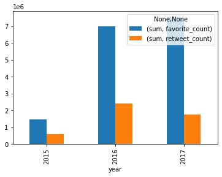

```python
m.plot(kind="bar")
```

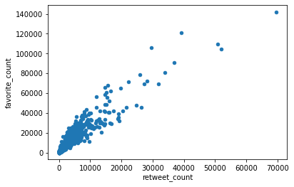

```python
tweet_all.plot( x='retweet_count',y="favorite_count",kind="scatter")
```